# Lab 5: Logistic Regression

Maarten van der Velde

# 1. Preparation

```r
library(mgcv)
library(itsadug)
library(plyr)
library(dplyr)
library(colorspace)
```

Download data

```r
download.file("http://www.jacolienvanrij.com/Courses/LOT2018/data/dat_gaze.rda", "dat_gaze.rda")
load("dat_gaze.rda")
head(dat)
```

|  | Subject | TRIAL_INDEX | EYE_TRACKED | SAMPLE_INDEX | TIMESTAMP | Event | blocking | Time | EyeRecorded | ACCURACY | RESPONSE | RT_FromAudioEnd | RT_FromObjectStart | art1_start | art1_end | art1_dur | art1_word | subject_start | subject_end | subject_dur | modal_start | modal_end | modal_dur | modal_word | verb_start | verb_end | verb_dur | verb_word | art2_start | … |
| --- | --- | --- | --- | --- | --- | --- | --- | --- | --- | --- | --- | --- | --- | --- | --- | --- | --- | --- | --- | --- | --- | --- | --- | --- | --- | --- | --- | --- | --- | --- |
| 719 | g1_sk_nn | 1 | Right | 17 | 18956742 | g1_sk_nn.1 | Experiment | -600 | Right | 99 | XXX | 999999 | 999999 | 0 | 132.2896 | 132.2896 | The | 132.2896 | 682.3135 | 550.0239 | 682.3135 | 859.2167 | 176.9033 | will | 859.2167 | 1252.71 | 393.4931 | grab | 1252.71 | … |
| 720 | g1_sk_nn | 1 | Right | 37 | 18956762 | g1_sk_nn.1 | Experiment | -580 | Right | 99 | XXX | 999999 | 999999 | 0 | 132.2896 | 132.2896 | The | 132.2896 | 682.3135 | 550.0239 | 682.3135 | 859.2167 | 176.9033 | will | 859.2167 | 1252.71 | 393.4931 | grab | 1252.71 | … |
| 721 | g1_sk_nn | 1 | Right | 57 | 18956782 | g1_sk_nn.1 | Experiment | -560 | Right | 99 | XXX | 999999 | 999999 | 0 | 132.2896 | 132.2896 | The | 132.2896 | 682.3135 | 550.0239 | 682.3135 | 859.2167 | 176.9033 | will | 859.2167 | 1252.71 | 393.4931 | grab | 1252.71 | … |
| 722 | g1_sk_nn | 1 | Right | 77 | 18956802 | g1_sk_nn.1 | Experiment | -540 | Right | 99 | XXX | 999999 | 999999 | 0 | 132.2896 | 132.2896 | The | 132.2896 | 682.3135 | 550.0239 | 682.3135 | 859.2167 | 176.9033 | will | 859.2167 | 1252.71 | 393.4931 | grab | 1252.71 | … |
| 723 | g1_sk_nn | 1 | Right | 97 | 18956822 | g1_sk_nn.1 | Experiment | -520 | Right | 99 | XXX | 999999 | 999999 | 0 | 132.2896 | 132.2896 | The | 132.2896 | 682.3135 | 550.0239 | 682.3135 | 859.2167 | 176.9033 | will | 859.2167 | 1252.71 | 393.4931 | grab | 1252.71 | … |
| 724 | g1_sk_nn | 1 | Right | 117 | 18956842 | g1_sk_nn.1 | Experiment | -500 | Right | 99 | XXX | 999999 | 999999 | 0 | 132.2896 | 132.2896 | The | 132.2896 | 682.3135 | 550.0239 | 682.3135 | 859.2167 | 176.9033 | will | 859.2167 | 1252.71 | 393.4931 | grab | 1252.71 | … |

```r
str(dat)
```

```
'data.frame':   41201 obs. of  51 variables:
 $ Subject           : Factor w/ 26 levels "g1_bk_n","g1_js_nn",..: 6 6 6 6 6 6 6 6 6 6 ...
 $ TRIAL_INDEX       : int  1 1 1 1 1 1 1 1 1 1 ...
 $ EYE_TRACKED       : Factor w/ 2 levels "Left","Right": 2 2 2 2 2 2 2 2 2 2 ...
 $ SAMPLE_INDEX      : int  17 37 57 77 97 117 137 157 177 197 ...
 $ TIMESTAMP         : num  1.9e+07 1.9e+07 1.9e+07 1.9e+07 1.9e+07 ...
 $ Event             : Factor w/ 312 levels "g1_sk_nn.1","g3_dw_nn.1",..: 1 1 1 1 1 1 1 1 1 1 ...
 $ blocking          : chr  "Experiment" "Experiment" "Experiment" "Experiment" ...
 $ Time              : num  -600 -580 -560 -540 -520 -500 -480 -460 -440 -420 ...
 $ EyeRecorded       : Factor w/ 2 levels "Left","Right": 2 2 2 2 2 2 2 2 2 2 ...
 $ ACCURACY          : int  99 99 99 99 99 99 99 99 99 99 ...
 $ RESPONSE          : chr  "XXX" "XXX" "XXX" "XXX" ...
 $ RT_FromAudioEnd   : int  999999 999999 999999 999999 999999 999999 999999 999999 999999 999999 ...
 $ RT_FromObjectStart: int  999999 999999 999999 999999 999999 999999 999999 999999 999999 999999 ...
 $ art1_start        : int  0 0 0 0 0 0 0 0 0 0 ...
```

[output cut: 37 more lines]

```r
summary(dat$Time)
```

```
   Min. 1st Qu.  Median    Mean 3rd Qu.    Max.
 -660.0    60.0   720.0   721.2  1380.0  2560.0
```

Select 2000 ms window:

```r
dat <- droplevels(dat[dat$Time > -500 & dat$Time < 2000,])
```

## Question 1: Relation proportion and logit

**How do positive logit values relate to proportions**

Proportions greater than 0.5 have a positive logit value.

**What value does logit value 0 translate to?**

0.5

**Advantage of logit scale over proportion scale?**

It is not truncated on either side, unlike a proportion scale, which is limited at 0 and 1.

# 2. Visualisation

```r
avg <- ddply(dat, c("Time", "verb_type"), summarise,
      IA_1 = sum(IA_1_C)/ sum(NSamples),
      IA_2 = sum(IA_2_C)/ sum(NSamples),
      IA_3 = sum(IA_3_C)/ sum(NSamples),
      IA_4 = sum(IA_4_C)/ sum(NSamples))
emptyPlot(c(0,2000), c(0,.5), v0=0,
          xlab="Time (ms)", ylab="Proportion",
          main="Gaze during sentence\nRestricting Verb")
with(avg[avg$verb_type=="Restricting",], lines(Time, IA_1, col=1, lwd=2) )
```

```r
with(avg[avg$verb_type=="Restricting",], lines(Time, IA_2, col=2, lwd=2) )
with(avg[avg$verb_type=="Restricting",], lines(Time, IA_3, col=3, lwd=2) )
```

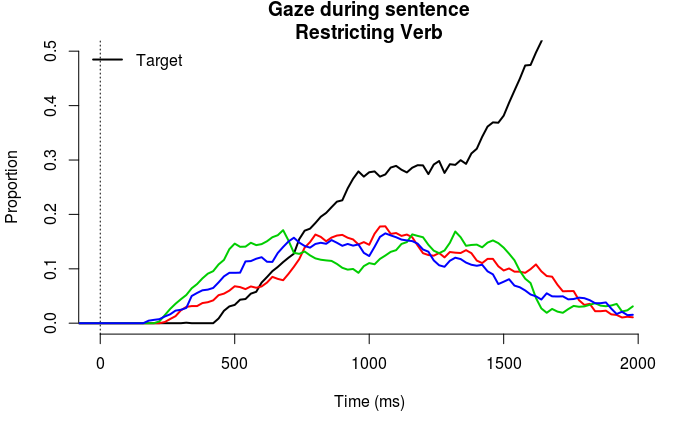

```r
with(avg[avg$verb_type=="Restricting",], lines(Time, IA_4, col=4, lwd=2) )
legend('topleft', legend=c("Target"), col=1, lwd=2, bty='n')
```

```r
emptyPlot(c(0,2000), c(0,.5), v0=0,
          xlab="Time (ms)", ylab="Proportion",
          main="Gaze during sentence\nNonRestricting Verb")
with(avg[avg$verb_type=="NonRestricting",], lines(Time, IA_1, col=1, lwd=2) )
```

```r
with(avg[avg$verb_type=="NonRestricting",], lines(Time, IA_2, col=2, lwd=2) )
with(avg[avg$verb_type=="NonRestricting",], lines(Time, IA_3, col=3, lwd=2) )
```

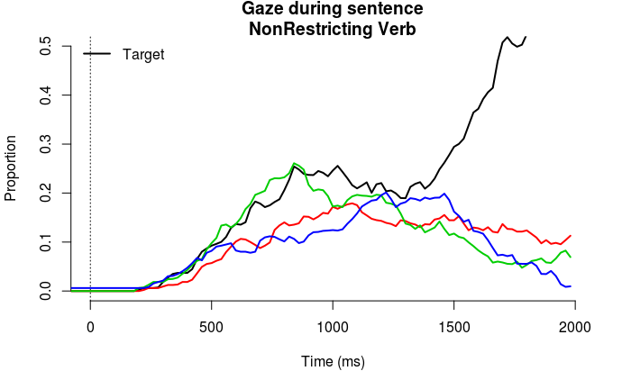

```r
with(avg[avg$verb_type=="NonRestricting",], lines(Time, IA_4, col=4, lwd=2) )
legend('topleft', legend=c("Target"), col=1, lwd=2, bty='n')
```

# 3. Start analysis

```r
dat$Target <- with(dat, cbind(IA_1_C, NSamples)) # make 2d column (why?!?) to store both area of interest 1 fixation count (IA_1_C) and the total number of samples in that time step.
dat$Distractor2 <- with(dat, cbind(IA_2_C, NSamples))

dat$verb_type <- as.factor(dat$verb_type) # gams expects factor
```

```r
m1 <- bam(Target ~ verb_type + s(Time, by=verb_type), data=dat, family='binomial')
```

```
fitted probabilities numerically 0 or 1 occurred
```

Note that this gives a warning because the first part of the data is all zeroes (see the plots above). People cannot look anywhere in the first 200ms; they’re still moving their eyes.

One solution: trim the first part off the timeseries:

```r
m1 <- bam(Target ~ verb_type + s(Time, by=verb_type), data=dat[dat$Time > 200,], family='binomial')
summary(m1)
```

```
Family: binomial
Link function: logit

Formula:
Target ~ verb_type + s(Time, by = verb_type)

Parametric coefficients:
                      Estimate Std. Error z value Pr(>|z|)
(Intercept)          -1.736114   0.006735 -257.79   <2e-16 ***
verb_typeRestricting -0.656544   0.041617  -15.78   <2e-16 ***
---
Signif. codes:  0 ‘***’ 0.001 ‘**’ 0.01 ‘*’ 0.05 ‘.’ 0.1 ‘ ’ 1

Approximate significance of smooth terms:
                                  edf Ref.df Chi.sq p-value
s(Time):verb_typeNonRestricting 8.879  8.994  16687  <2e-16 ***
s(Time):verb_typeRestricting    8.927  8.996  15920  <2e-16 ***
---
Signif. codes:  0 ‘***’ 0.001 ‘**’ 0.01 ‘*’ 0.05 ‘.’ 0.1 ‘ ’ 1

R-sq.(adj) =    0.2   Deviance explained = 20.5%
fREML = 1.4174e+05  Scale est. = 1         n = 27093
```

Interpretation: the negative intercept (remember: it’s on a logit scale) means that the average proportion of looks at the target is below 0.5. You can transform it back to a proportion for interpretation using `plogis`. Similarly, when the verb is restricting, the proportion of looks to the target is even lower.

The edf values of the smooths are very close to their maximum, so it makes sense to allow more edf, by setting k = “some higher value”.

```
Summary:
    * verb_type : factor; set to the value(s): NonRestricting, Restricting.
    * Time : numeric predictor; with 30 values ranging from 220.000000 to 1980.000000.
```

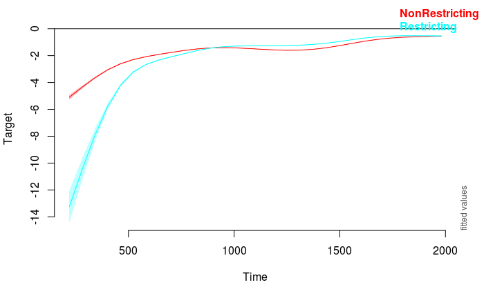

```r
plot_smooth(m1, view = "Time", plot_all = "verb_type")
```

(Be aware that the confidence intervals are very small, indicating that the model is overconfident.)

This plot is on a logit scale, we can transform it back to a proportion scale using the `plogis` transformation in R.

```
Summary:
    * verb_type : factor; set to the value(s): NonRestricting, Restricting.
    * Time : numeric predictor; with 30 values ranging from 220.000000 to 1980.000000.
```

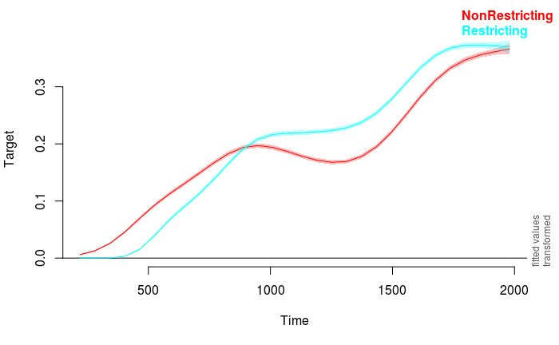

```r
plot_smooth(m1, view = "Time", plot_all = "verb_type", transform = plogis)
```

Look at the residuals. Note that we would not expect normal residuals since the data are binomial.

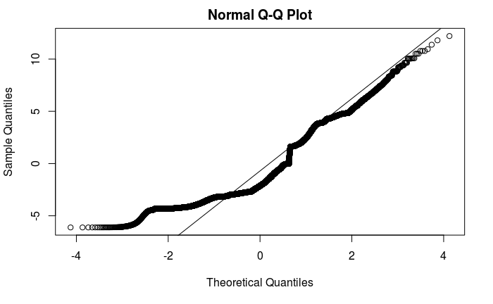

```r
qqnorm(resid(m1))
qqline(resid(m1))
```

Are there autocorrelations in the residuals?

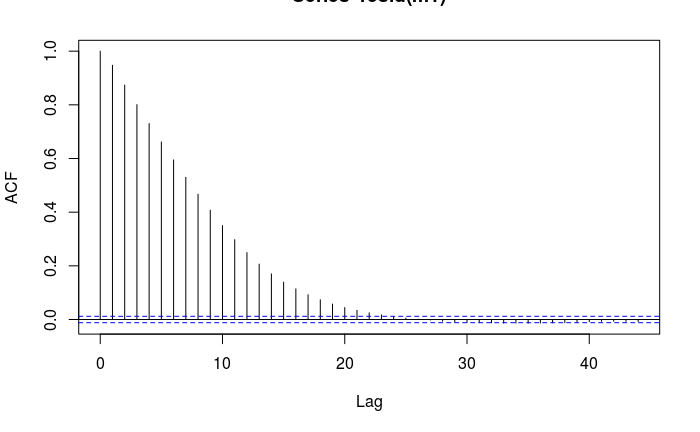

```r
acf(resid(m1))
```

Yes! Not surprising since we don’t account for random effects in the model.